# Aaron Judge Playoff Performance 2024

In this project, I examine Aaron Judge’s widely publicized and uncharacteristic postseason hitting deficiency. I am interested in utilizing various visualizations to consider the approach of pitchers in the postseason and why they were successful against him. I will utilize several visuals, from heatmaps to strikezone plots, as well as some brief data calculations to demonstrates any interesting findings.

# Plots and Data

The first thing I want to examine is where the pitches that Judge faced were located. This can provide insights into understanding pitch locations that he had difficulty with, especially noting the frequency with which each pitch was thrown to him. I will do this with heatmaps of each pitch he faced, including the frequency with which he saw each pitch.

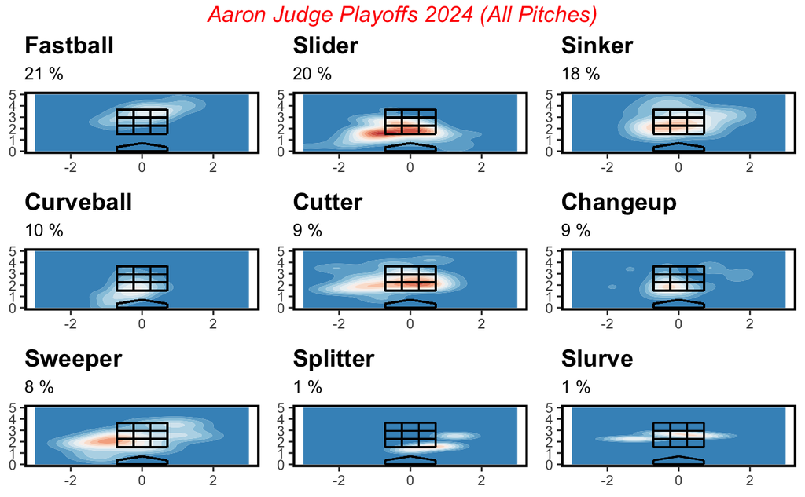

While these figures indicate that Judge faced the highest proportion of his pitches as fastballs, I find it very interesting that sliders comprised 20% of the pitches he saw, with other pitches frequently seeing the bottom of the zone as is evident through the heatmaps. According to Savant data, [Judge saw 26.8% four-seamers and 17.9% sliders in the regular season](https://baseballsavant.mlb.com/savant-player/aaron-judge-592450?stats=statcast-r-hitting-mlb) - this shift indicates potentially a slight change in the approach pitchers carried towards attacking Judge at the lower part of the zone as opposed to trying to get him to swing and miss at fastballs up in the zone. The curveball (Curve and Knucle Curve here) had a combined percenage of around [7% in the regular season](https://baseballsavant.mlb.com/savant-player/aaron-judge-592450?stats=statcast-r-hitting-mlb), and the postseason saw this figure jump to 10%, noting that the pitch mix and location focus altered in the postseason. Overall, it is evident through these heatmaps that pitchers focused on pitching to Judge low in the zone with a myriad of pitch offerings.

I wanted to further compare these figures with Judge’s hits in the postseason to see if there was a noticeable difference between the pitches he saw and the pitches that he was able to get hits on.

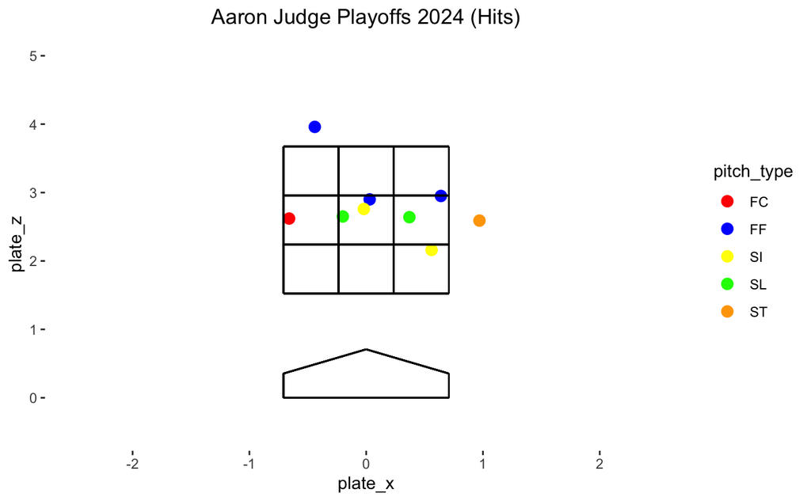

From this plot, it is very clear that Judge’s hits were in the middle third of the zone. As seen with the hit plots, pitchers mitigated this by throwing to him low and many times away to mitigate the potential for hard contact, of which Judge is obviously capable.

As Judge faced numerous pitchers in the playoffs, I was interested in further seeing which pitchers fared the best against Judge and how they performed with certain pitches. I did so by examining all of the pitchers he faced in the postseason, as well as creating statistics based on each pitch and pitcher for the individual pitch performances in terms of inducing whiffs (noted as “swinging strikes” in the Savant dataset - this may lead to different calculations compared to other industry sources). I additionally included counting statistics (strikeouts, hits, batting average) as a supplement.

| Name | total_pitches | whiffs | whiff_percentage | mean_ev | strikeouts | hits | batting_avg |
| --- | --- | --- | --- | --- | --- | --- | --- |
| Brusdar Graterol | 12 | 1 | 8.333333 | 82.78000 | 0 | 1 | 1.0 |
| Anthony Banda | 5 | 0 | 0.000000 | NaN | 0 | 0 | NaN |
| Michael Kopech | 2 | 0 | 0.000000 | 100.90000 | 0 | 0 | 0.0 |
| Landon Knack | 8 | 0 | 0.000000 | 88.70000 | 0 | 0 | 0.0 |
| Brent Honeywell | 3 | 0 | 0.000000 | 107.80000 | 0 | 1 | Inf |
| Ryan Brasier | 6 | 2 | 33.333333 | NaN | 0 | 0 | NaN |
| Yoshinobu Yamamoto | 17 | 5 | 29.411765 | 79.90000 | 2 | 0 | 0.0 |
| Tanner Bibee | 15 | 4 | 26.666667 | 93.50000 | 1 | 0 | 0.0 |
| Hunter Gaddis | 17 | 5 | 29.411765 | 81.74000 | 2 | 1 | 0.5 |
| Emmanuel Clase | 8 | 1 | 12.500000 | 103.10000 | 0 | 1 | 1.0 |

[output cut: 12 more lines]

| Name | pitch_type | total_pitches | whiffs | whiff_percentage | mean_ev | strikeouts | hits | batting_avg |
| --- | --- | --- | --- | --- | --- | --- | --- | --- |
| Brusdar Graterol | SI | 10 | 1 | 10.00000 | 82.78 | 0 | 1 | 1 |
| Anthony Banda | SL | 4 | 0 | 0.00000 | NaN | 0 | 0 | NaN |
| Anthony Banda | SI | 1 | 0 | 0.00000 | NaN | 0 | 0 | NaN |
| Michael Kopech | FF | 1 | 0 | 0.00000 | 100.90 | 0 | 0 | 0 |
| Brusdar Graterol | SL | 2 | 0 | 0.00000 | NaN | 0 | 0 | NaN |
| Michael Kopech | FC | 1 | 0 | 0.00000 | NaN | 0 | 0 | NaN |
| Landon Knack | CU | 4 | 0 | 0.00000 | 92.60 | 0 | 0 | 0 |
| Landon Knack | FF | 3 | 0 | 0.00000 | NaN | 0 | 0 | NaN |
| Brent Honeywell | SL | 2 | 0 | 0.00000 | 107.80 | 0 | 1 | Inf |
| Brent Honeywell | FF | 1 | 0 | 0.00000 | NaN | 0 | 0 | NaN |

[output cut: 59 more lines]

I selected four pitchers out of this selection that I believed to be strong performers against Judge based on the metrics: Yoshinobu Yamamoto (17 pitch sample, nearly 30% whiff rate and low average EV (79.9 MPH) with 2 Ks, strong performing slider (50% whiff)), Michael Wacha (18 pitch sample, only 22.22% whiff but low 74.53 average EV, 1 K, strong performing Sinker (40% whiff)), Tanner Bibee (15 pitch sample, 26.67% whiff with elevated average EV (93.5 MPH) but strong performing cutter (40% whiff) and 1 K), and Angel Zerpa (14 pitch sample, no whiff percentage but lower 79.03 MPH average EV, 0 hits allowed).

I wanted to examine their performance against Judge individually. Below are plots for each pitcher and their performance against Judge, separated out to demonstrate EVs and and whiffs.

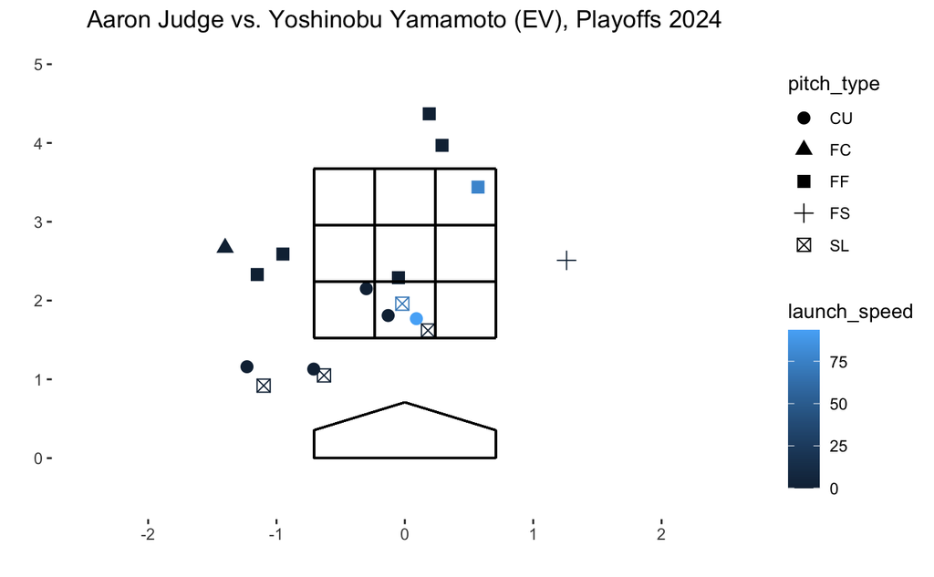

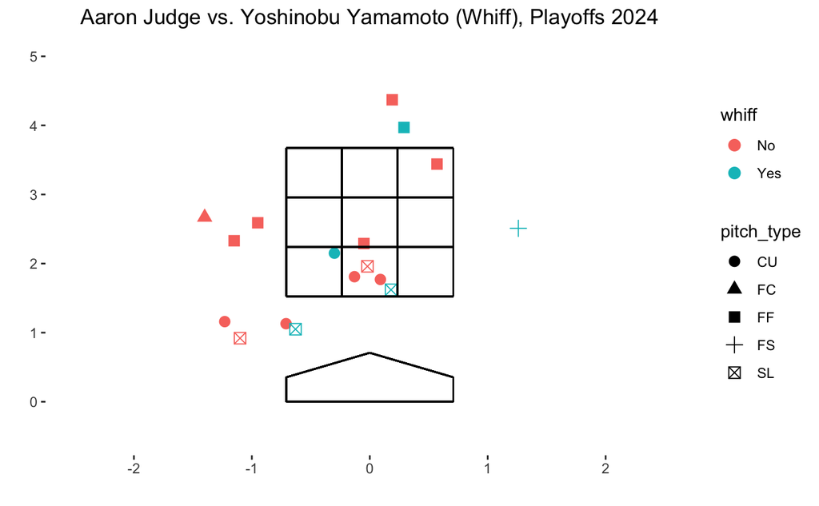

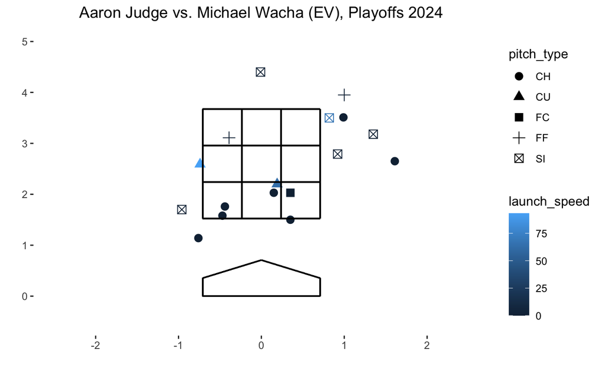

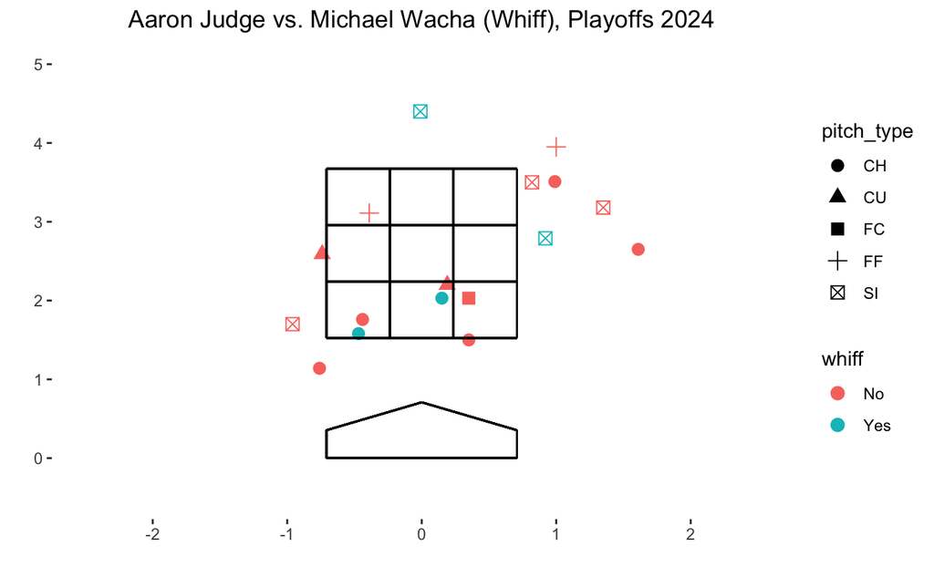

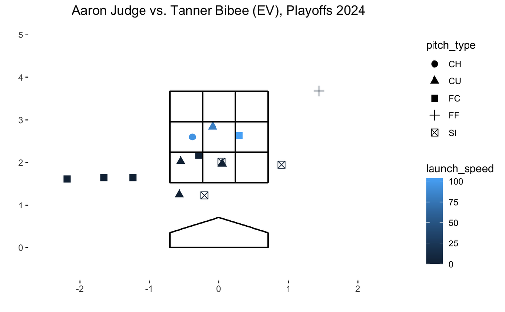

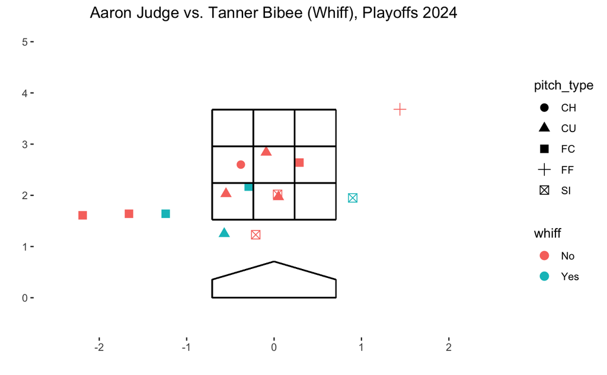

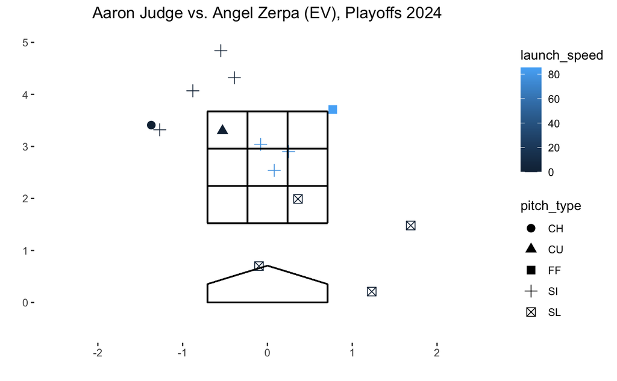

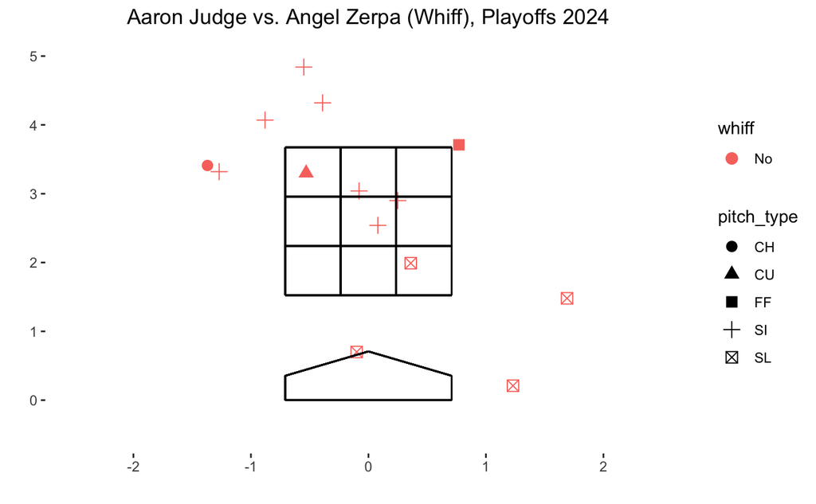

Yamamoto: Stayed low and away for the most part, and this worked - he allowed some contact low in the zone, but otherwise was successful in inducing whiffs in the lower part of the zone, especially with 2 sliders. He seemed to not challenge Judge near the top of the zone.

Wacha: Sat a little higher in the zone compared to Yamamoto, though away from the middle for the most part to avoid hard contact. Wacha worked inside on Judge primarily, a unique approach, though again saw whiffs at the lower part of the zone with the changeup. Kept the sinker out of the zone completely, and saw 2 whiffs.

Bibee: Was more similar to Yamamoto, though caught more of the zone consistently, evident by the three balls put in play that were all in the middle zone or very close. Otherwise, the theme of low and away was consistent, as he induced whiffs on three pitches (1 curve, 2 cutter) away from Judge. Challenged Judge above the middle of the zone even less than Yamamoto. 1 sinker inside for a whiff is consistent with Wacha - also consistent with the theme of sitting low.

Zerpa: Contact on his sinkers that were in the middle of the zone. Zerpa being the only lefty of the group provides an interesting tilt to the data - Judge seemed less keen on swinging at sliders coming in on him compared to before with a pitcher like Yamamoto where it was away from him. Zerpa did not allow any hits, but he also walked Judge twice - though this is a small sample, it is clear that Zerpa was essentially pitching around Judge as much as possible.

The first three pitchers saw success from staying low in the zone. For the most part, all of the pitchers avoided the middle of the zone, with Zerpa essentially pitching around Judge with his non-competitive sinkers high and away. It is clear that Judge struggled most low and low-away, especially with off-speed pitches. Yamamoto and Bibee were the best at targeting this weakness.

I wanted to reinforced my view that the middle of the zone was a common area of avoidance for pitchers. This should naturally be the case for anyone facing Judge logically, though I wanted to examine Judge’s regular season home runs to view where in the zone he saw these pitches.

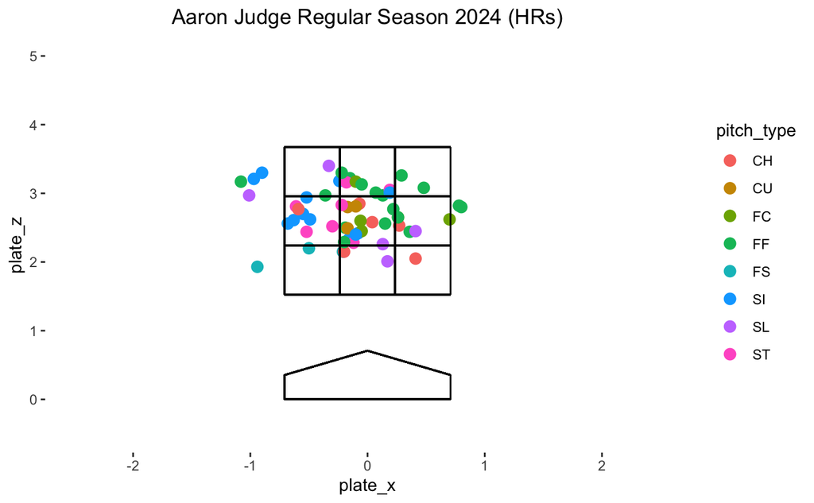

This plot aligns with what is seen with Judge’s postseason hits chart. It is clear he excels in the middle third of the zone (naturally), and as seen with the four pitchers, it is clear that most of his contact came from this area - those pitchers excelled since they kept the ball away from this zone frequently.

To tie these visualizations together, I wanted to examine Judge’s regular season and postseason whiff tendencies in plots and statistics. Through plots, I was able to discern the pitches that Judge swung and missed on through a strike zone plot, the heatmap of his swing and misses, and an estimate of the swing and miss percentages for judge based on the filtered data acquired through Statcast (may be varied compared to other source estimates).

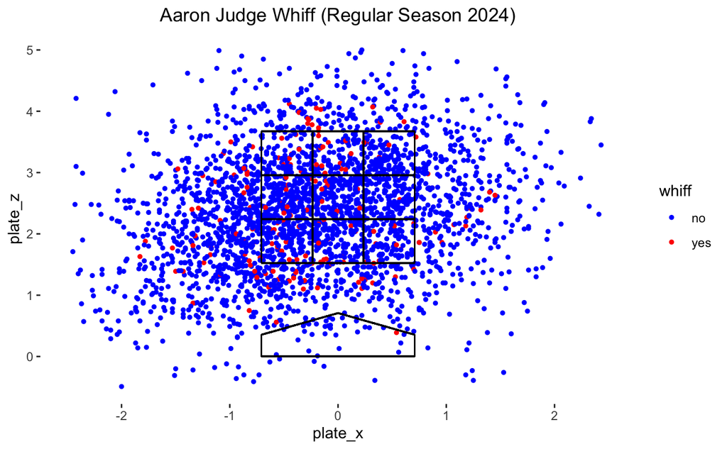

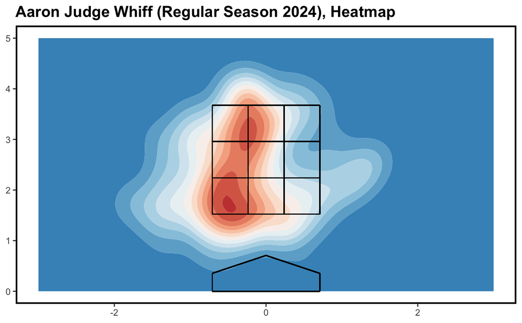

| n |
| --- |
| 5.892548 |

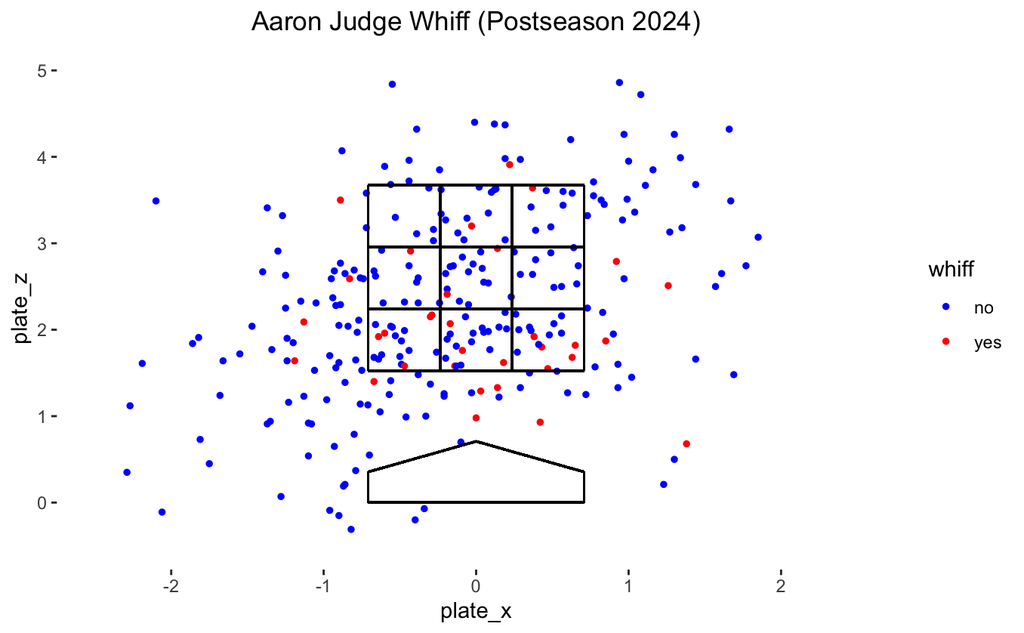

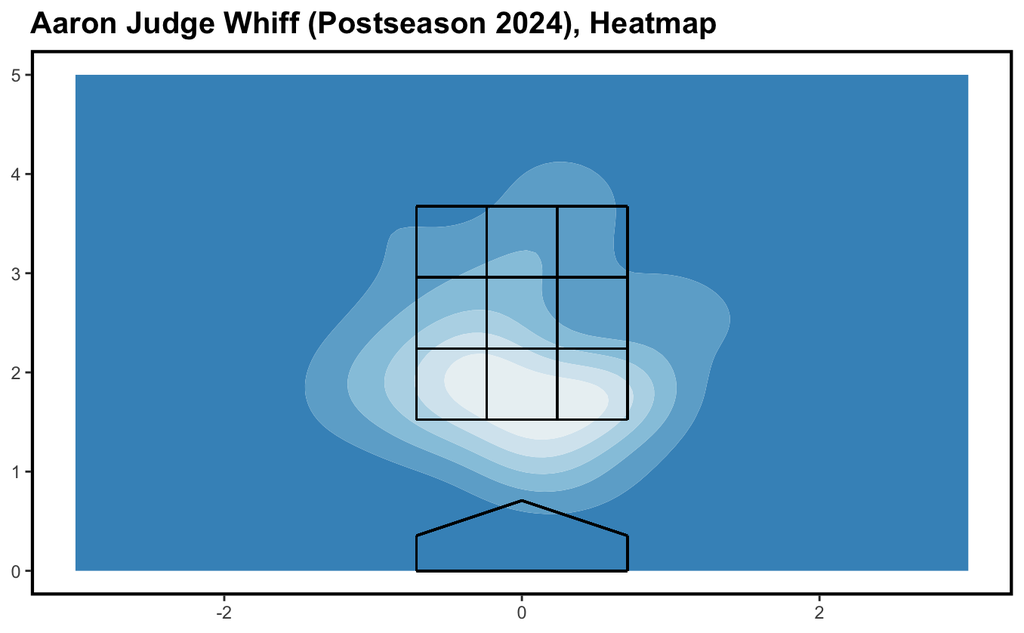

| n |
| --- |
| 12.08791 |

From these plots, it is evident that Aaron Judge’s whiff tendencies were slightly altered across the regular season and post-season. It is clear from the plots themselves that Judge tended to see more low pitches for whiffs in the post-season, signaling a high percentage of sliders and off-speed pitches compared to the regular season (which we saw early with the 20% slider percentage that we saw). It is thus clear that among the pitchers examined, they were very successful with low pitches to get Judge to whiff, especially sliders, curveballs, and chanegups. Further, the data itself presented here indicates that Judge’s whiff rate was up altogether in the playoffs. From the calculations here, it appears that Judge’s swinging strike percentage went from 5.89% in the regular season to 12.09% in the postseason. While this data is subject to variability based on available data, it appears that the general trend of Aaron Judge whiffing more in the postseason has validity.

# Conclusions

Through this exploration, it is evident that Aaron Judge had uncharacteristic difficulties throughout the post-season. As he saw a ~2.1%increase in sliders into the post season and a ~5.8% decrease in fastballs with a shift to more low pitches, where he was unable to adjust and saw an elevated whiff percentage in the post-season. Pitchers that were especially successful against him included Yoshinobu Yamamoto, Michael Wacha, and Tanner Bibee (with Angel Zerpa essentially pitching around him), where the first three executed well to keep the ball away from the middle third of the zone as much as possible, where most of Judge’s hard contact in the regular season came from.

While not many conclusive theories can be drawn from this examination, it is clear that Judge struggled in the playoffs, and the information presented indicates that it likely is attributable to both changed pitcher approach (low and away, sliders, etc.) but also his personal mentality and approach at the plate, which are harder to quantify. Going off of this, an interesting area for continued analysis would be to examine pitches Judge saw by count and with different numbers of runners on base, which could account a little more for his approach. With this, an examination of his hitting tendencies in high leverage versus low leverage situations, both in the regular season and playoffs, could give insight into understanding his performance discrepancies.

# Additional

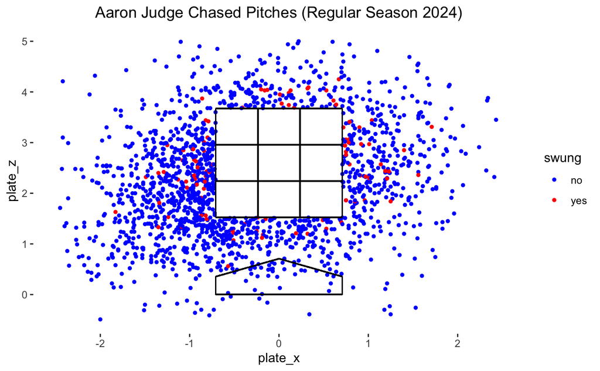

| n |
| --- |
| 57.78163 |

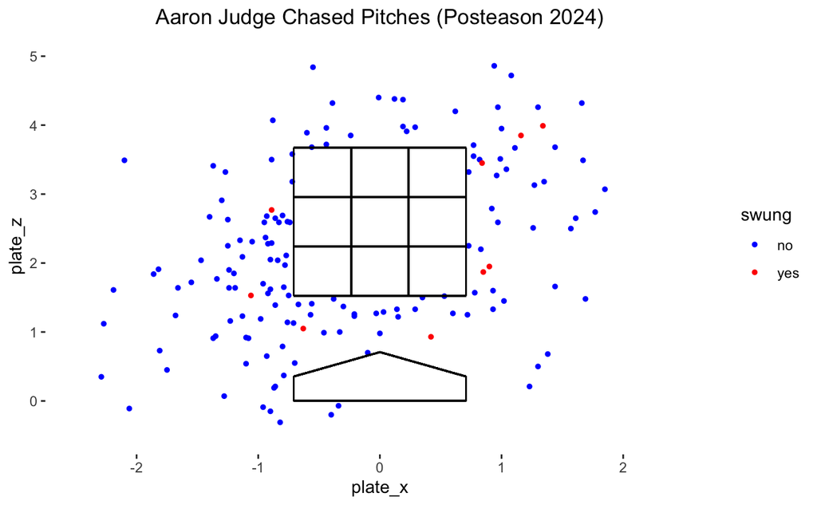

| n |
| --- |
| 57.50916 |